# OpTiles Package Manual

Giorgia Migliaccio

# Introduction

**OpTiles** is an R package aimed to extend the standard tiling-windows approach by refining region definitions, supporting data-driven prioritization, and enhancing interpretation of heterogeneous or complex datasets.

To improve region definition in DNA methylation analysis, OpTiles implements a data-adaptive framework that considers the non-uniform nature of CpG distribution and sequencing coverage. By repositioning tiling windows to better reflect the actual distribution of sequenced CpGs, OpTiles preserves region size while increasing the retention of informative CpGs that might otherwise be excluded by genome fixed-window strategies. Beyond optimizing tile boundaries, OpTiles incorporates intra-region variability as an additional metric to assess the reliability and biological relevance of regional methylation summaries. OpTiles quantifies it alongside CpG density to offer a composite score, the InfoScore, designed to support informed region selection. This score helps to prioritize regions where methylation values are likely to be more stable and representative, and others that are instead more variable and inconsistent in methylation value that might need more careful evaluation. In parallel, the annotation and overlap-scoring functions provided by OpTiles offer researchers a finer-grained toolkit for contextualizing methylation patterns. OpTiles integrates with methylKit, [**methylKit**](https://bioconductor.org/packages/release/bioc/html/methylKit.html) workflow (Akalin et al., 2012), however most OpTiles functions operate on methylation data paired with genomic coordinates. This makes them compatible with data from other sequencing platforms or technologies, offering broader applicability beyond methylKit.

The package introduces several key features:

- **Optimization of tile positions** to better reflect CpG density
- **Assessment of intra-region variability** using the standard deviation of methylation values within a region
- **Calculation of an InfoScore** that integrates CpG count and variability to prioritize stable, high-confidence regions
- **Annotation and overlap scoring** using genomic features from public datasets (via `biomaRt`), including customizable overlap metrics

This manual will guide you through the OpTiles functions, demonstrating key OpTiles features. The functions are organized into four modules that reflect the main ways users can interact with the package. Each module, however, can also operate independently, provided the input is in the required format.

1. Load and prepare data
2. Build and optimize regions
3. Compute intra-region variability
4. Annotate regions

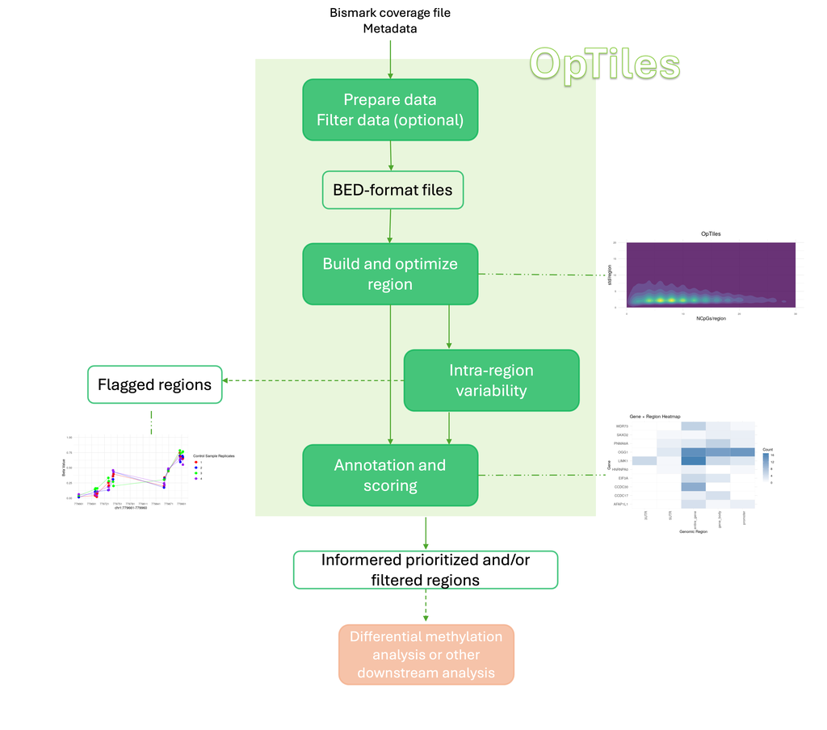

```r
knitr::include_graphics("how_to_use/graphical_abstract_manual.png")
```

## Data Compatibility and Usage Context

OpTiles natively imports data from Bismark coverage files, but its functions (with the exception of data-loading utilities) are also compatible with BED-like data frames, provided that genomic coordinates and beta values are included. Coordinates may be supplied either as a single string in the format chr:start-end or as three separate columns (chr, start, end). Function-specific input requirements are described in detail throughout the manual to guide proper usage. While OpTiles has been primarily developed and tested on Reduced Representation Bisulfite Sequencing (RRBS) data, it is not restricted to this application: because the framework operates directly on genomic locations and methylation values, it can be applied to other methylation datasets as well. The core features—including tiling optimization, intra-region variability analysis, and region annotation—can be performed independently or in combination, depending on the user’s analytical needs.

## Example script

An example script that shows how to use the functions, is also shown in the /how_to_use/OpTiles_example_script.R.

# Load and prepare data

When loading Bismark coverage files (`*.bismark.cov.gz`), **OpTiles** provides the function `load_methylation_data()`, which wraps several core functions from the methylKit package. Specifically, it integrates methRead, getMethylationStats, getCoverageStats, filterByCoverage, normalizeCoverage, and unite. The output of this process is a `methylBase` object, consistent with the standard data structures used in methylKit. Since this function relies directly on methylKit utilities, it can only be applied to data formats supported by methylKit.

```r
meth <- load_methylation_data(
  repository = "/RRBS_data/",
  sample_name_variable = "sample",
  treatment_variable = "treatment_vector",
  mincov = 10,
  individual_sample_plot = TRUE,
  filter_high_percentage = TRUE,
  normalization_coverage = TRUE,
  method_normalization = "median",
  metadata = metadata
)
```

- *metadata*: A data frame containing metadata for the samples. It includes: A column with sample names that match Bismark file names (excluding .bismark.cov.gz). A numeric column encoding treatment groups. A condition column that derive from a substring or pattern in sample names; it can help to create groups of interest that are recalled in other functions (e.g.`filter_by_beta_in_cpgs` or `compute_beta_sd_regions`)
- *repository*: Character. Path to the directory containing Bismark coverage files named with the sample names as in metadata followed by an underscore (“_“).
- *sample_name_variable*: Character. Name of the column in metadata with sample names.
- *treatment_variable*: Character. Name of the column in metadata indicating treatment group as numeric values.
- *mincov*: Integer. Minimum read coverage required per CpG site (e.g., 10).
- *individual_sample_plot*: Logical. If TRUE, generates coverage (with `methylKit::getCoverageStats()`) and methylation (with `methylKit::getMethylationStats()`) distribution plots for each sample. Useful for quality control.
- *filter_high_percentage*: Logical. If TRUE, removes CpG sites with coverage in the top 0.1% to avoid technical artifacts.
- *normalization_coverage*: Logical. If TRUE, normalizes coverage across samples before uniting.
- *method_normalization*: Character. Normalization method to use. Options are “median” (default) or “mean”.
- *assembly*: Character. Genome assembly name (default: “hg38”).

```
## # A tibble: 4 × 3
##   sample treatment_vector condition
##   <chr>             <dbl> <chr>
## 1 72_C_1                0 72_C
## 2 72_C_2                0 72_C
## 3 72_C_3                0 72_C
## 4 72_C_4                0 72_C
```

This function returns a methylBase object containing methylation values across all samples, which can be passed to other methylKit or OpTiles functions for downstream analysis. Once loaded with `load_methylation_data()`, the data can be filtered, visualized, and analyzed using the subsequent functions provided in the **OpTiles** workflow. For example, when used in combination with `analyze_methylation_stats()`, the tool generates plots that provide an overview of coverage and methylation levels across all samples. For coverage plots, the input required is a data frame or matrix containing a coverage column. For methylation plots instead, the function requires a beta value matrix, the corresponding metadata, and the name of the column in the metadata that contains the sample identifiers.

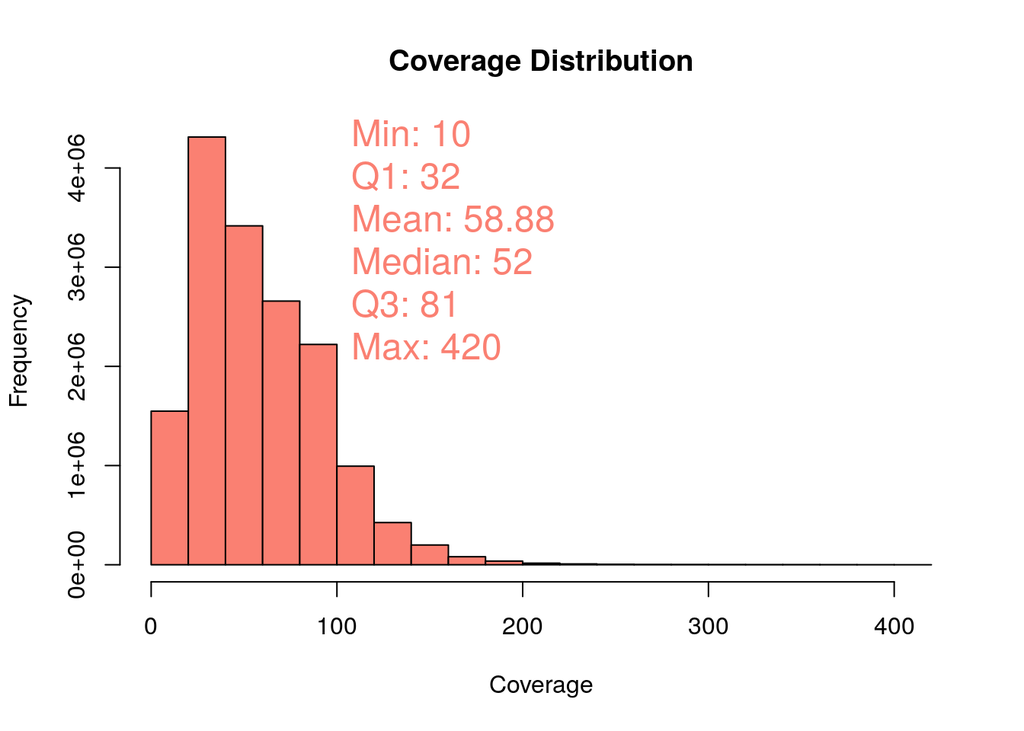

```r
# to obtain the data frame from MethylKitObject and see the statistics
methdf <- getData(meth)

analyze_methylation_stats(
  meth = methdf,
  variable_to_investigate = "coverage",
  position_text = 100)
```

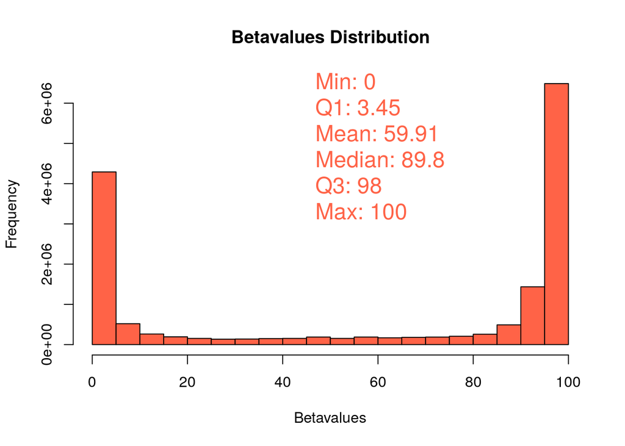

```r
# to compute the betavalues from the MethylKitObject and see the statistics
betavalue <- percMethylation(meth)

analyze_methylation_stats(
  meth = as.data.frame(betavalue),
  variable_to_investigate = "betavalue",
  position_text = 60,
  metadata = metadata,
  sample_name_variable = "sample")
```

Before building the regions, CpGs can be filtered. High variability in CpG methylation values within a group of biological replicates (or any user-defined sample group representing a single condition) is unexpected and undesirable, since replicates are expected to show consistent patterns. To address this, CpGs can be filtered before building regions. The function `filter_by_beta_in_cpgs()` implements this approach by calculating, for each CpG, the difference between the maximum and minimum beta values within the group. CpGs where this difference equals or exceeds a user-specified threshold are excluded. The function returns a character vector of CpG genomic locations that pass the filter, i.e., sites where all groups show a delta beta below the threshold.

```r
groups_control <- unique(metadata$condition[metadata$treatment_vector == 0])
filtered_locations <- filter_by_beta_in_cpgs(
  betavalue_df = betavalue_df,
  threshold_delta_beta = 25,
  groups = groups_control
)

idx_filtering <- which(rownames(betavalue_df)%in% filtered_locations)

betavalue_filtered <- betavalue_df[idx_filtering,]
meth_filtered <- meth[idx_filtering,]
```

# Build and optimize regions

Using the `methylKit::tileMethylCounts` function, users can define genomic regions (tiles) of a specific dimension (e.g. 300bp) for methylation analysis, that can be visualized with OpTiles functions. Before doing that, it is necessaty to convert the output of `methylKit::tileMethylCounts` to a dataframe with `methylKit::getData()` as showed before with the individual CpGs, and the `analyze_methylation_stats()` function generates plots that summarize coverage and methylation levels across all samples within each region, as done previously on individual CpGs sites.

The approach used with `methylKit::tileMethylCounts` is based on a tiling-window strategy that divide the genome into fixed-size segments and summarize the methylation signals of CpGs within each of them. Specifically, the counts of methylated (Cs), unmethylated (Ts), and total coverage are aggregated across all CpGs falling within a given tile. While this ensures systematic coverage across the genome, it relies on the assumption of uniformly distributed CpGs and consistent sequencing depth which limits its suitability for targeted approaches like RRBS, where CpGs are enriched in specific genomic regions. As a result, fixed-size tiles may cover sparsely sequenced areas, diluting true signals and adding noise. Although filtering tiles by CpG density is a common solution, misaligned region boundaries can still lead to the loss of informative regions. To overcome these limitations, OpTiles introduces a data-driven adaptive binning approach that refines tile definitions based on the actual CpG distribution.

The first step is to extract CpGs that fall within the defined tiles. The `map_cpg_to_regions()` function performs this by computing overlaps between CpG and region genomic coordinates, assigning each CpG to its corresponding region. The function requires as input the genomic locations of both CpGs and regions. The input is flexible as long as it includes genomic locations. You may provide either a `methylKitObject` (as in the example) or a data frame with genomic coordinates specified as “chr”, “start”, and “end”. The function will then generate the corresponding genomic ranges from these coordinates. This allows users to visualize the distribution of CpG density across regions using `do_histogram_with_statistics` function.

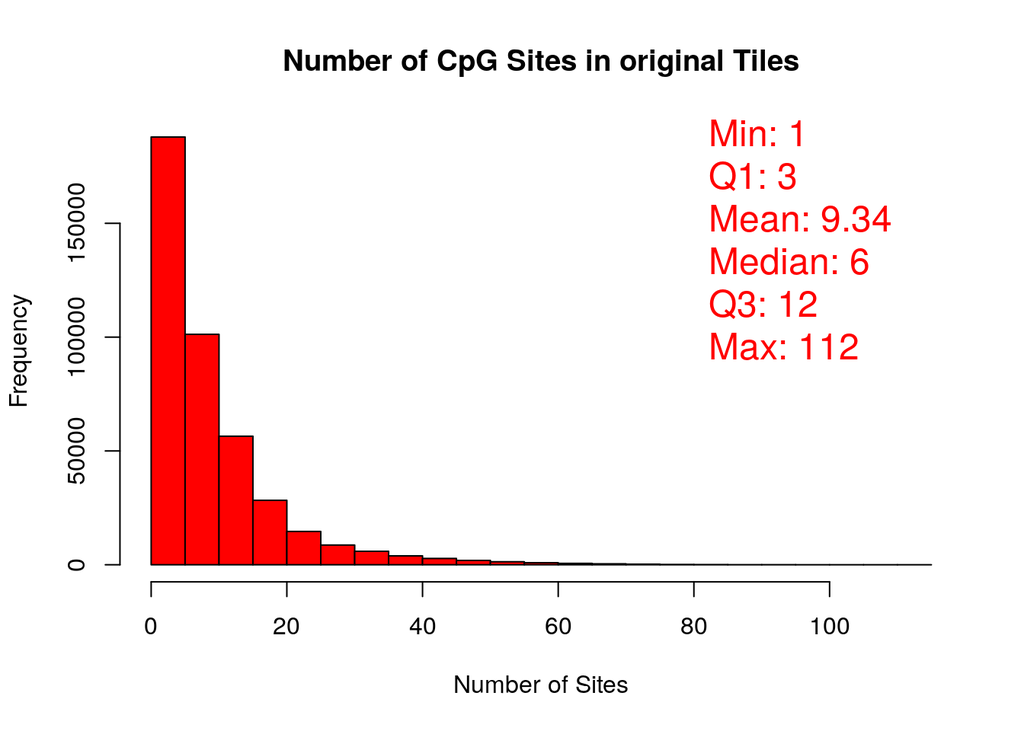

```r
#Assign to each region the CpGs
regions_cpgs <- map_cpg_to_regions(methdf = meth_filtered,
                                   region = tiles)
# Compute the number of CpG sites per region
N_cpg_regions <- as.data.frame(table(regions_cpgs$region_id))
N_cpg_regions_before_merging <- N_cpg_regions

# Load and execute the histogram function
do_histogram_with_statistics(
  vect = as.numeric(N_cpg_regions$Freq),
  title = "Number of CpG Sites in original Tiles",
  x_axis = "Number of Sites",
  text_position = 80,
  color_plot = "red"
)
```

As next step, **Optiles enables the repositioning of the tiles based on the actual distribution of sequenced CpGs.** This ensures that tiles are anchored in informative regions, particularly useful in target-based datasets (e.g. RRBS) where coverage is sparse and localized. Importantly, while tile locations are adjusted to match the data, the original tile size is preserved to maintain consistency in downstream comparisons. **OpTiles** identifies pairs of consecutive tiles, defined as directly adjacent, non-overlapping pairs. For each candidate tiles pair, OpTiles maps all CpG positions and calculates two distances: (1) AD is the distance between the first CpG of the first tile and the last CpG of the second; (2) BC is the distance between the last CpG of the first tile and the first CpG of the adjacent one.If CpGs are tightly clustered (AD < tile size), the tiles are merged into a single region spanning all CpGs from both tiles. If AD > tile size but BC < tile size, indicating a narrow gap between CpG clusters, OpTiles scans the span to generate fixed size windows and selects the one with the highest CpG count, retaining the most downstream in case of a tie. If neither AD nor BC meet these criteria, the tiles remain unchanged.

This optimization is performed using the `merging_consecutive_regions()` function, which takes as input the original CpGs genomic location matrix, the tiles dataframe (obtained with `methylKit::getData` of the tiles produced by methylKit), and a threshold distance between CpGs (as default use the dimension of the tiles, in our case we used 300bp). This step may take several minutes, depending on the size of your dataset.

By default, OpTiles merges consecutive regions across the entire dataset. In the example script (`how_to_use/OpTiles_example_script.R`), you can choose to run the analysis on a smaller subset (e.g., regions from chromosome 1) for a quicker demonstration. Alternatively, you can enable parallel processing to accelerate computation on the full dataset. For reference, on a system equipped with an AMD EPYC Rome processor (128 cores, 2 GHz) and 456 GB RAM, this step required approximately 210 seconds when parallelized across 25 cores, using an input dataset comprising 415K regions and 3.8 million CpGs.

```r
region_length = 300
regions_plus_merged_regions <- merging_consecutive_regions(meth_filtered,
                                                           tiles,
                                                           da_thr = region_length,
                                                           cb_thr = region_length)
```

The output is an improved, data-driven tile definition as a dataframe containing new optimized regions. Additionally, you can visualize the new CpGs density distribution.

```
##  chr  start    end          region_id
##    1  10497  10796   chr1:10497-10796
##    1  51593  51892   chr1:51593-51892
##    1  61954  62253   chr1:61954-62253
##    1  88705  89004   chr1:88705-89004
##    1 134999 135298 chr1:134999-135298
##    1 591456 591755 chr1:591456-591755
```

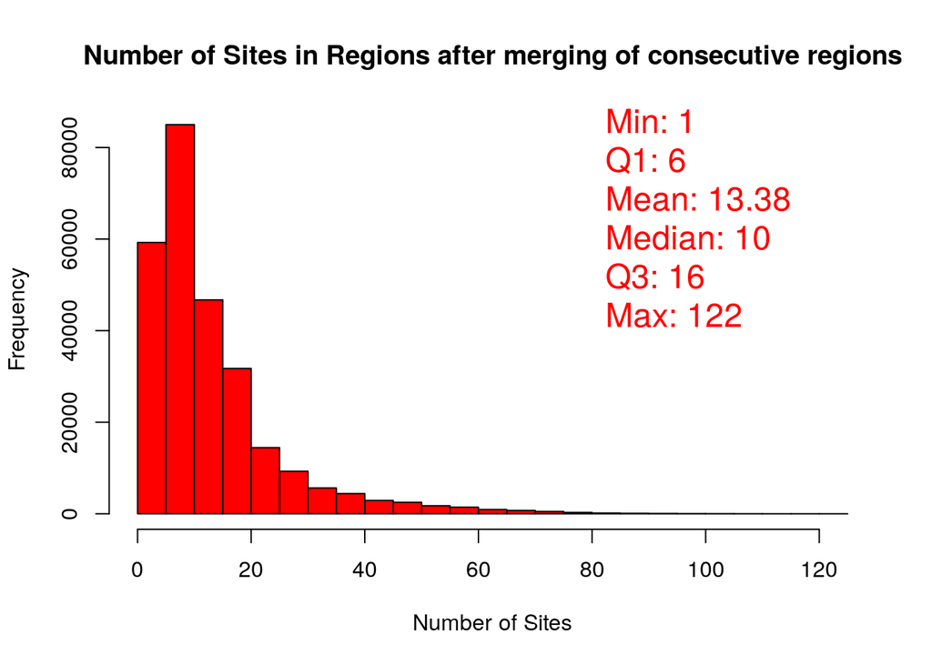

# Compute intra-region variability

The summarization approach used when summarizing DNA methylation over regions reduces each region to a single average methylation value, without accounting for intra-region variability. Although colocalised CpGs are generally expected to exhibit coordi-nated methylation patterns (Eckhardt et al. 2006, Affinito et al. 2020), heterogeneity in methylation states is frequently observed (Elliott et al. 2015). Such variability can be influenced by technical factors, such as PCR bias, sequencing coverage, different read lengths or stochastic erosion (Scherer et al. 2020). OpTiles adds this missing layer of context by enabling the identification of regions with high intra-region variability and guiding decisions on whether to summarize a genomic locus as a region or retain the finer resolution of individual analysis. In details, Optiles evaluates intra-region methylation variability by calculating the standard deviation (SD) of methylation values within each region across individual samples or biological replicates.

Before using this function, beta values must first be assigned to the new regions using the `assign_beta_merged_regions()` function, that requires as input the new regions, the CpG genomic locations, and the beta value matrix.

```r
regions_cpgs_merged <- assign_beta_merged_regions(regions = regions_plus_merged_regions,
                                                  cpgs = meth_filtered,
                                                  betavalue = betavalue_filtered)
```

Once this assignment is complete, the `compute_beta_sd_regions()` function can be used to compute the intra-region variability. It requires as input the CpG-level methylation values (beta values) , their corresponding mapped genomic regions (e.g., the output of the `assign_beta_merged_regions()` function, shown below), and the sample group across which the variability should be computed. The function also visualizes the distribution of the intra-region variability values, helping to identify regions with high or low variability. Alternatively, the input data frame for `compute_beta_sd_regions()` does not need to come directly from the previous function, as long as it includes the beta values, region coordinates, and CpG locations in the required format.

```
##         region_id           cpg_id    72_C_1    72_C_2 72_C_3   72_C_4
##  chr1:10497-10796 chr1:10497-10497  98.44961 100.00000  100.0 99.39024
##  chr1:10497-10796 chr1:10525-10525 100.00000  99.06542   97.6 97.56098
##  chr1:10497-10796 chr1:10542-10542  96.12403  98.13084  100.0 95.73171
##  chr1:10497-10796 chr1:10563-10563  96.87500  99.06542   96.8 99.39024
##  chr1:10497-10796 chr1:10571-10571  96.87500  95.32710   98.4 98.78049
##  chr1:10497-10796 chr1:10577-10577  98.44961  99.06542   96.0 98.17073
```

```
sd_regions <- compute_beta_sd_regions(regions_cpgs = regions_cpgs_merged$regions_merged_cpg_beta,
                                      groups = groups_sd)
```

```
##           region_id      72_C
##              <char>     <num>
##    chr1:10497-10796  1.431285
##    chr1:51593-51892  8.171043
##    chr1:61954-62253 12.695105
##    chr1:88705-89004  2.605767
##  chr1:134999-135298  7.914733
##  chr1:591456-591755 13.649084
```

At this point, you can optionally filter regions based on the number of CpGs and their methylation variability (SD). To support this, **OpTiles** introduces the **InfoScore**, a simple yet effective metric that combines **CpG density** with **intra-region variability**. Regions that contain more CpGs and show lower variability receive higher InfoScores, since they are considered more reliable due to consistent methylation value and higher number of CpGs. This scoring system helps prioritize high-confidence regions.

$$\text{InfoScore} = \frac{\text{N}_{CpG}}{\text{Region Length}} \times
\frac{1}{\text{SD}}$$
In here you can see some example of intra-region variability and infoscore values, in particular an example of low infoscore and high infoscore.

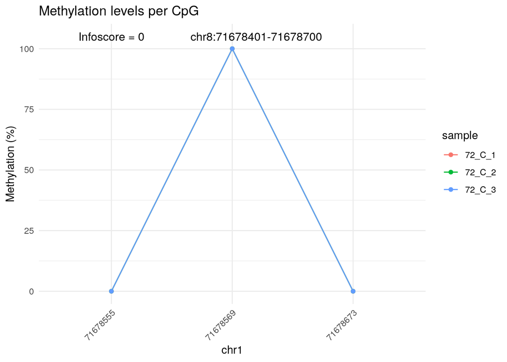

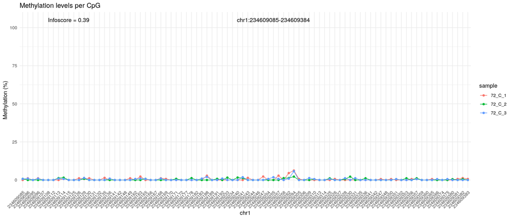

You can filter regions based on an NCpGs or intra-region variability threshold, or prioritize those with the highest infoscores. These regions can be converted into a new methylKit-compatible object using the `convert_to_methylobj()` function, enabling downstream analysis such as differential methylation analysis with `methylKit::calculateDiffMeth`. This function takes as input the vector of genomic coordinates of the optimized regions (in the format of the region_id “chrX:start-end”) and the original methylKitObject containing CpG-level data. If you only need the data frame with the new regions and their beta values, you can apply `methylKit::getData()` to the output of `convert_to_methylobj()`.

```
##           region_id
##              <char>
##    chr1:10497-10796
##    chr1:51593-51892
##    chr1:61954-62253
##    chr1:88705-89004
##  chr1:134999-135298
##  chr1:591456-591755
```

```
#convert to methylkitobject
filtered_regions_obj <- convert_to_methylobj(regions_location = filtered_regions,
                                             cpgs_methyl_obj = meth_filtered)
```

# Annotation regions

Once the regions or the differentially methylated regions (DMRs) have been identified, they can be annotated of to known genomic features (e.g. promoters, exons, CpG Island). For instance, the ENSEMBL biomaRt database provides comprehensive gene annotation data, including genomic locations of exons, UTRs, and full gene bodies. To simplify this process, OpTiles includes a dedicated function that retrieves gene annotations directly from biomaRt and extracts relevant gene features. This allows users to annotate regions with biologically meaningful context. Since biomaRt does not directly provide promoter regions, users can specify the promoter distance to TSS by setting the promoter_distance parameter when calling the function.

The `biomart_annotation()` function supports the following arguments:

- biomart_database: Name of the biomaRt database to query (e.g., “ensembl”).
- biomart_dataset: Dataset within the biomaRt database (e.g., “hsapiens_gene_ensembl”).
- chromosome_vector: Vector of chromosome names to filter (e.g., c(“1”, “2”, “X”)).
- selected_attributes: Specific biomaRt attributes to retrieve.
- attributes_page: Page in biomaRt from which to select attributes.
- gene_biotype: Filter for a specific gene biotype (e.g., “protein_coding”).
- filter_gene_biotype: A vector of gene biotypes to include.
- promoter_distance: A numeric vector of length two defining upstream and downstream distances from TSS for promoter regions (e.g., c(1000, 200) that are respectively upstream and downstream).

```
annotation_df <- biomart_annotation(biomart_database = "ENSEMBL_MART_ENSEMBL",
                                    biomart_dataset = "hsapiens_gene_ensembl",
                                    chromosome_vector = c(as.character(1:22), "X", "Y", "MT"),
                                    selected_attributes = c('chromosome_name', 'start_position', 'end_position', 'hgnc_symbol',
                                                            'strand', 'transcription_start_site',
                                                            '5_utr_start', '5_utr_end', '3_utr_start', '3_utr_end', 'exon_chrom_start', 'exon_chrom_end',
                                                            'rank'),
                                    attributes_page = c("feature_page","structure"),
                                    gene_biotype = "chromosome_name",
                                    filter_gene_biotype = c(as.character(1:22), "X", "Y", "MT"),
                                    promoter_distance = c(500,100))
```

The output dataframe will be as the following:

```
##  gene                location   gene_loci strand
##  A1BG chr19:58345178-58353492 entire_gene     -1
##  A1BG chr19:58353438-58353492        5UTR     -1
##  A1BG chr19:58345183-58347021        3UTR     -1
##  A1BG chr19:58353404-58353492       exon1     -1
##  A1BG chr19:58353292-58353327       exon2     -1
##  A1BG chr19:58352928-58353197       exon3     -1
```

```r
# Example with biomaRt database
annotated <- map_regions(sample_to_map =  regions_plus_merged_regions, annotation = annotation_df, origin_annotation = "gene")
```

```
# Example with CpGs Island downloaded on
CpG_island <- read_delim("/CpG_island.txt")
colnames(CpG_island) <- c("chr","start","end","cpg_id")
CpG_island <- as.data.frame(CpG_island)
CpG_island$location <- paste0(CpG_island$chr,":",CpG_island$start,"-",CpG_island$end)

CPGI_annotated <- map_regions(sample_to_map =  DMRall_regions_cpgs,annotation = CpG_island, origin_annotation = "CpGI")
```

The output of the function (i.e., `annotated`) is a data frame in which each `region_id` is annotated with its corresponding `annotation_region`, associated `gene`, and `gene_loci` For each pair of regions, the function computes overlap metrics, including: - `overlap_windows`: the specific window of overlap, - `overlap_bp`: the number of overlapping base pairs, - `pct_tile`: the percentage of the tile length that overlaps, - `pct_merged`: the percentage of the region_id that overlaps, and - `overlapping_NCpGs`: the number of CpG sites within the overlapping region.

These metrics quantify the extent of overlap between the region_id and the annotation_region.

```
##         annotation_regions                 region_id            overlap_window overlap_bp   pct_tile pct_merged overlapping_NCpGs  gene   gene_loci
##  chr10:100009838-100009947 chr10:100009674-100009973 chr10:100009838-100009947        110 100.000000 36.6666667                 1 DNMBP        5UTR
##  chr10:100009847-100010447 chr10:100009674-100009973 chr10:100009847-100009973        127  21.131448 42.3333333                 1 DNMBP    promoter
##  chr10:100009947-100009947 chr10:100009674-100009973 chr10:100009947-100009947          1 100.000000  0.3333333                 1 DNMBP   gene_body
##  chr10:100042193-100042426 chr10:100042055-100042354 chr10:100042193-100042354        162  69.230769 54.0000000                 1  CPN1        3UTR
##  chr10:100042193-100042573 chr10:100042055-100042354 chr10:100042193-100042354        162  42.519685 54.0000000                 1  CPN1   gene_body
##  chr10:100042193-100081869 chr10:100042055-100042354 chr10:100042193-100042354        162   0.408297 54.0000000                 1  CPN1 entire_gene
```

This allows us to easily quantify how many regions exhibit any overlap or exceed a specified overlap threshold with the annotation of interest. It also enables testing how different filtering criteria affect the number and extent of overlaps.

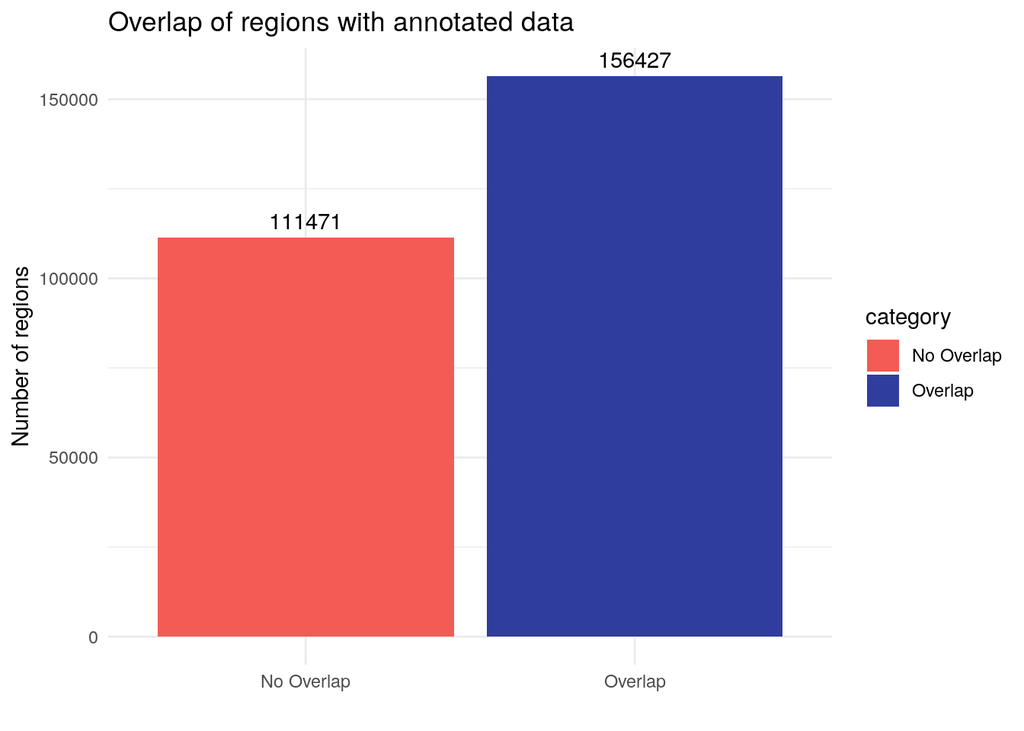

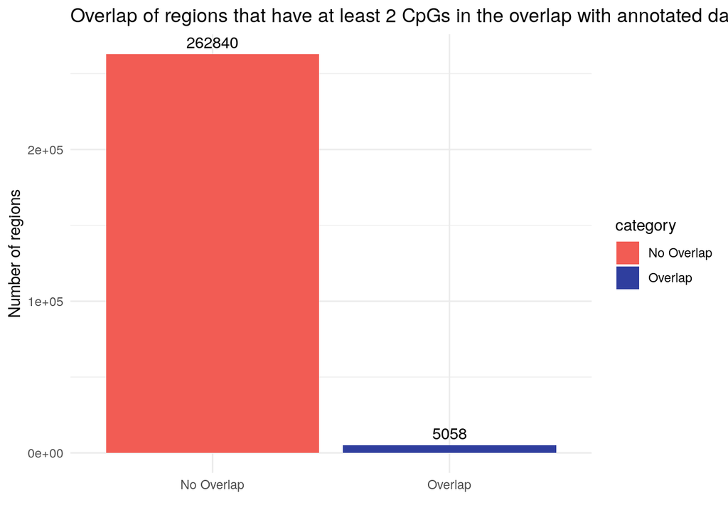

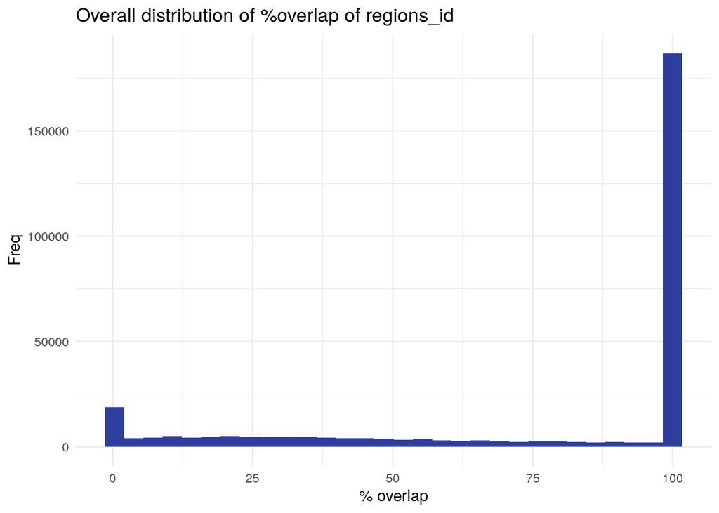

By selecting a subset of genes and, for example, grouping all exons under the gene body (as in the script below), you can visualize how many regions have been mapped to each specific genomic feature.

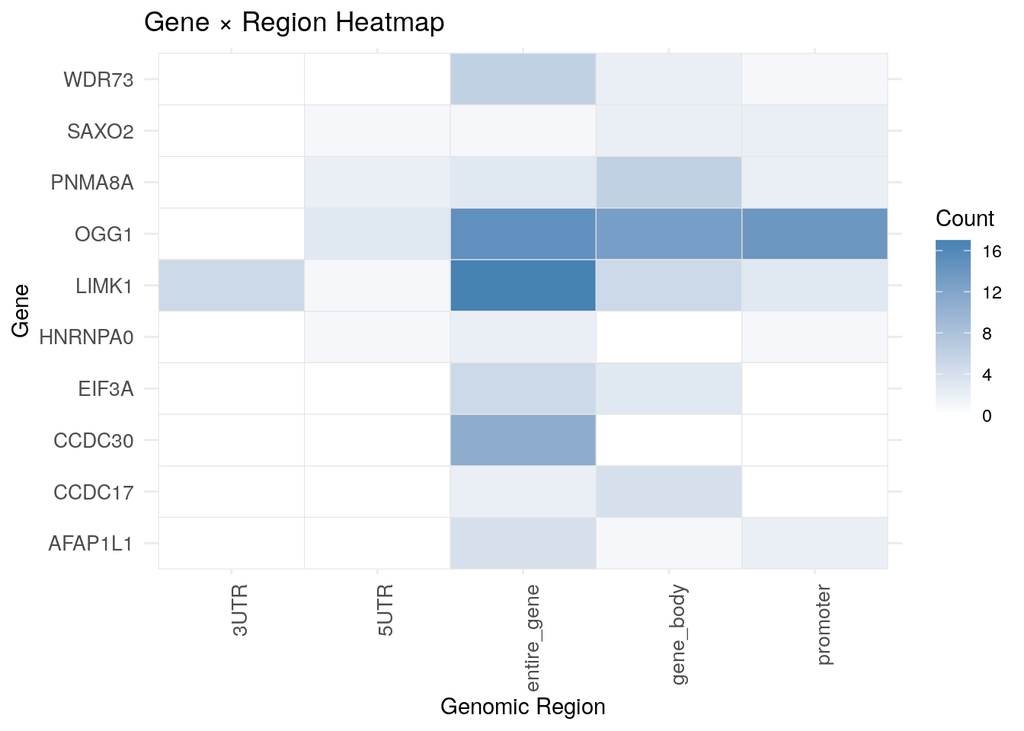

```r
#Example of plot

annotated[which(!(annotated$gene_loci %in% c("3UTR", "5UTR", "promoter","entire_gene"))), "gene_loci"] <- "gene_body"

# Count occurrencies
count_long <- annotated %>%
    count(gene, gene_loci)%>%
    complete(gene, gene_loci, fill = list(n = 0))

count_long <- count_long[order(count_long$n, decreasing = T),]
set.seed(263)
sample_genes <- sample(count_long$gene,size = 10)

# Heatmap
  p<-ggplot(count_long[count_long$gene %in% sample_genes,], aes(x = gene_loci, y = gene, fill = n)) +
    geom_tile(color = "grey90") +
    scale_fill_gradient(low = "white", high = "steelblue") +
    theme_minimal() +
    theme(
      axis.text.x = element_text(angle = 90, hjust = 1, size = 10),
      axis.text.y = element_text(size = 10),
      strip.text = element_text(size = 10, face = "bold")
      ) +
    labs(
      title = "Gene × Region Heatmap",
      x = "Genomic Region",
      y = "Gene",
      fill = "Count"
    )
```